# Exam 3 Skills Test

Joshua Nilsson

2026-04-21

## Question 1: Clean the table, and reconstruct the example graph.

In this section, I loaded in our data and converted the Salary columns into rows, the names of each column went to Rank and the values to Salary. I updated the professor titles so they were more clear. Then I dropped the unneeded information.

```r
salaries <- read.csv("FacultySalaries_1995.csv")
# Cleaning the csv to add the necessary rows for our graph.
clean_salaries <- salaries %>%
  pivot_longer(cols = matches("Salary"),
               names_to = "Rank",
               values_to = "Salary") %>%
  mutate(
    Rank = case_when(
      Rank == "AvgFullProfSalary"   ~ "Full",
      Rank == "AvgAssocProfSalary"  ~ "Associate",
      Rank == "AvgAssistProfSalary" ~ "Assistant",
      Rank == "AvgProfSalaryAll"    ~ "All",
      TRUE ~ Rank
    )
  ) %>%
  filter(Rank != "All", Tier != "VIIB")  #Excluding the "All" group and "VIIB" tier
```

I used a facet_wrap() to separate them by Tier, and theme() to alter the x-axis titles.

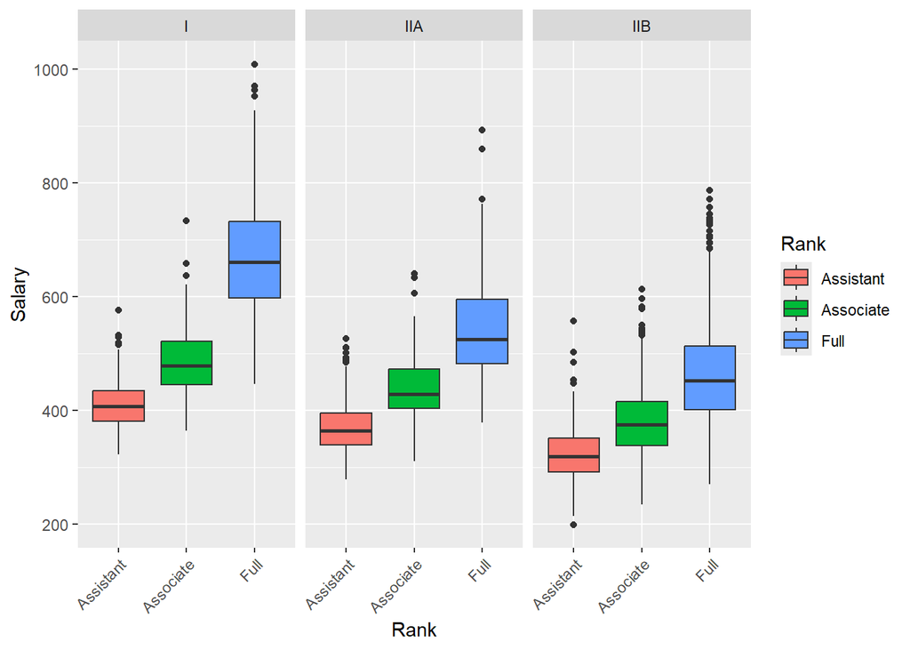

```r
# Plotting our graph.
plot <- clean_salaries %>%
  ggplot(aes(x = Rank, y = Salary, fill = Rank)) +
  geom_boxplot() +
  facet_wrap(~ Tier) +
  theme(axis.text.x = element_text(angle = 45, hjust = 1)) # Rotating the x-axis text.

plot
```

## Question 2: Build an ANOVA model that takes into consideration “State”, “Tier”, “Rank” on “Salary”

I used the aov() function to create the ANOVA model, then I summarized the model using summary().

```r
aovmod <- clean_salaries %>%
  aov(formula = Salary ~ State + Tier + Rank)
summary(aovmod) #Prints the summary output
```

```
##               Df   Sum Sq Mean Sq F value Pr(>F)
## State         50  5667124  113342   31.17 <2e-16 ***
## Tier           2  7072361 3536180  972.56 <2e-16 ***
## Rank           2 16526626 8263313 2272.66 <2e-16 ***
## Residuals   3297 11987752    3636
## ---
## Signif. codes:  0 '***' 0.001 '**' 0.01 '*' 0.05 '.' 0.1 ' ' 1
## 128 observations deleted due to missingness
```

## Question 3: Tidy the “Juniper_Oils.csv” data

To clean this, I took the various chemical columns and turned them into rows. The names became the ChemicalID, and the values became their concentration.

```r
oils <- read.csv("Juniper_Oils.csv", check.names = FALSE)
clean_oils <- oils %>%
  pivot_longer(cols = matches(c("alpha-pinene","para-cymene","alpha-terpineol","cedr-9-ene","alpha-cedrene","beta-cedrene","cis-thujopsene","alpha-himachalene","beta-chamigrene","cuparene","compound 1","alpha-chamigrene","widdrol","cedrol","beta-acorenol","alpha-acorenol","gamma-eudesmol","beta-eudesmol","alpha-eudesmol","cedr-8-en-13-ol","cedr-8-en-15-ol","compound 2","thujopsenal")),
               names_to = "ChemicalID",
               values_to = "Concentration")
```

## Question 4: Make a graph of Chemical Concentrations through time

For graphing, I used the ggplot function, and I made sure the proper inputs were in facet_wrap() function to match the example graph provided.

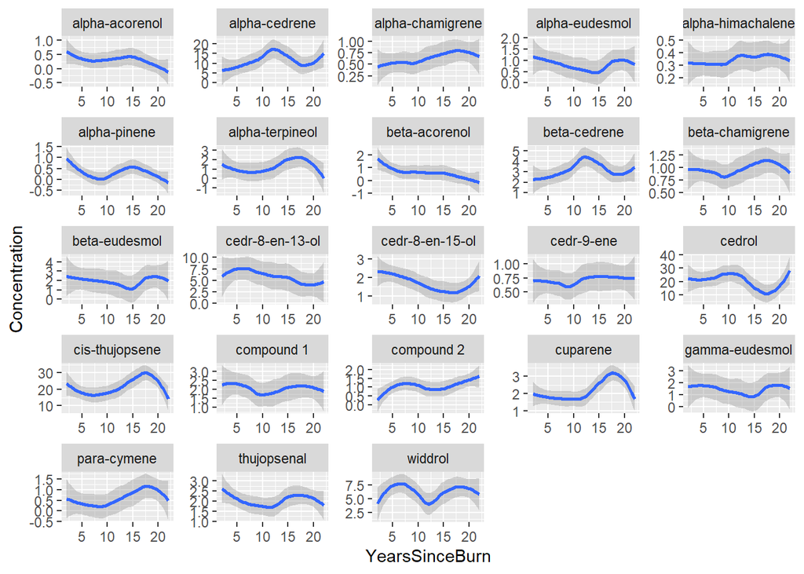

```r
plot2 <- clean_oils %>%
  ggplot(aes(x = YearsSinceBurn, y = Concentration)) +
  facet_wrap(~ChemicalID, axes = "all_x", scales = "free_y") +
  geom_smooth()

plot2
```

## Question 5: Create a GLM to find which chemicals are significantly affected by “Years Since Burn”

I used the glm() function to make the model, and I made sure the interactions between the ChemicalID and YearsSinceBurn were included to find the significant chemicals within the model. From there it was just a matter of cleaning the output term names and making sure it only displayed parameters that were below the 0.05 p-value threshold.

```r
glmmod <- glm(data = clean_oils, formula = Concentration ~ ChemicalID + ChemicalID:YearsSinceBurn)

glmmod %>%
  tidy() %>%
  filter(p.value < 0.05) %>%
  mutate(term = gsub("ChemicalID", "", term))
```

```
## # A tibble: 8 × 5
##   term                          estimate std.error statistic  p.value
##   <chr>                            <dbl>     <dbl>     <dbl>    <dbl>
## 1 alpha-cedrene                    7.88     1.93        4.08 4.97e- 5
## 2 cedr-8-en-13-ol                  7.62     1.93        3.95 8.72e- 5
## 3 cedrol                          22.5      1.93       11.7  5.12e-29
## 4 cis-thujopsene                  17.3      1.93        8.95 2.93e-18
## 5 widdrol                          5.82     1.93        3.01 2.69e- 3
## 6 alpha-cedrene:YearsSinceBurn     0.204    0.0998      2.04 4.13e- 2
## 7 cedrol:YearsSinceBurn           -0.247    0.0998     -2.48 1.35e- 2
## 8 cis-thujopsene:YearsSinceBurn    0.310    0.0998      3.10 2.00e- 3
```